# Project #1

Jakub Bednarz

```r
library(MASS)
library(sur)
library(GGally)
require(reshape2)
library(knitr)
library(lmtest)
```

# 1. Intro

First, let us load the data.

```r
data <- read.table("people.tab", header = TRUE)
knitr::kable(head(data))
```

| age | weight | height | gender | married | number_of_kids | pet | expenses |
| --- | --- | --- | --- | --- | --- | --- | --- |
| 25 | 61.7 | 121.12 | other | FALSE | 2 | ferret | 23.44299 |
| 37 | 63.9 | 145.00 | man | TRUE | 6 | dog | 96.83683 |
| 41 | 50.2 | 145.03 | woman | TRUE | 2 | hedgehog | 312.67693 |
| 43 | 72.4 | 179.90 | man | FALSE | 1 | dog | 447.42838 |
| 26 | 78.4 | 163.91 | man | FALSE | 1 | hedgehog | -78.22799 |
| 49 | 59.4 | 151.86 | woman | TRUE | 2 | ferret | 1241.98263 |

Few initial things to check are (i) the number of records; (ii) whether there are any missing values.

```r
cat("Num of records: ", dim(data)[1], "\n", sep = "")
```

```
## Num of records: 500
```

```r
cat("Any missing values? ", any(is.na(data)), "\n", sep = "")
```

```
## Any missing values? FALSE
```

We’ll need distinction between qualitative, quantitative, response and predictor variables.

```r
qual <- c("gender", "married", "pet")
quant <- c("age", "weight", "height", "number_of_kids", "expenses")
resp <- c("expenses")
pred <- setdiff(colnames(data), resp)
```

# 2. Graphs

First, a scatter plot for quantitative variables:

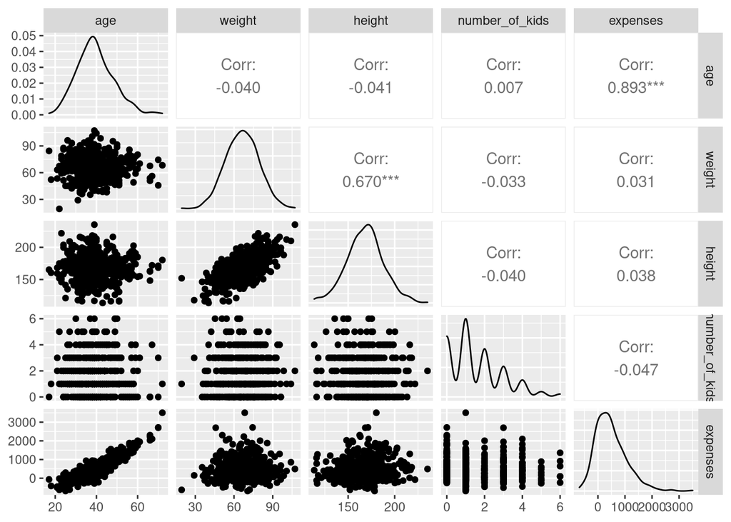

```r
ggpairs(data[quant], progress = FALSE)
```

Next, a box plot for a single quantitative variable:

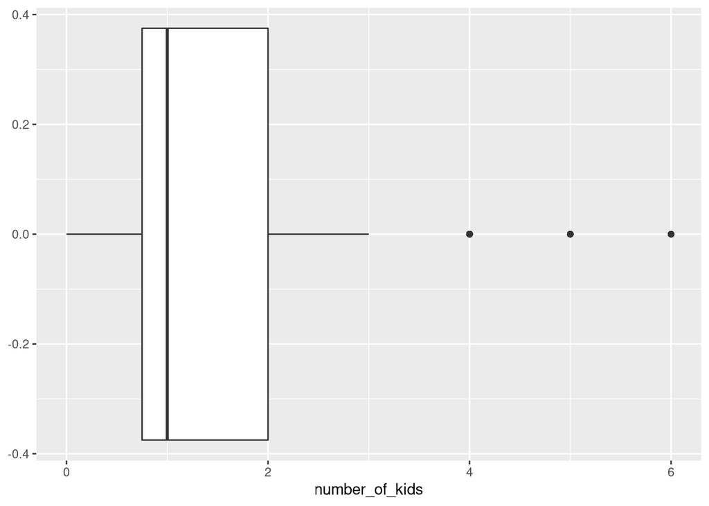

```r
chosen_quant <- sample(quant, 1)
ggplot(data, aes_string(chosen_quant)) +
    geom_boxplot()
```

and a bar plot for a single qualitative variable:

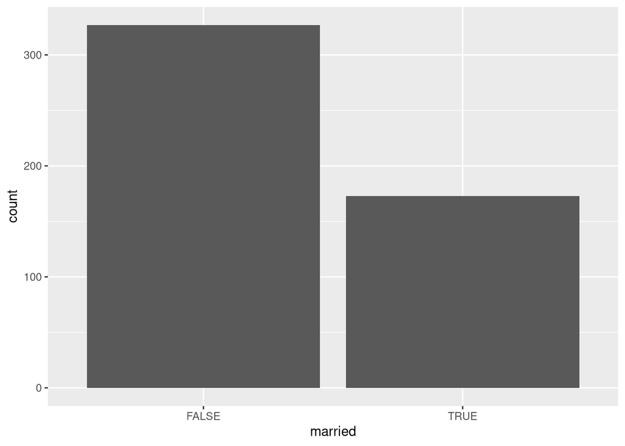

```r
chosen_qual <- sample(qual, 1)
ggplot(data, aes_string(chosen_qual)) +
    geom_bar()
```

# 3. Hypothesis testing I

## 3.1. $\mu$

The first hypothesis is on the mean of height: $H_0$ is that the mean of height is $170$ cm, $H_1$ that it is less than that.

This we can test using $t$-test. According to the lecture slides, this test assumes that the samples in question come from a normal distribution and are independent. In fact we can use a weaker assumption, i.e. that the estimator of $\mu$ is normally distributed, which follows asymptotically from CLT, and here, as $n = 500$, should indeed hold. Let’s look at the graph:

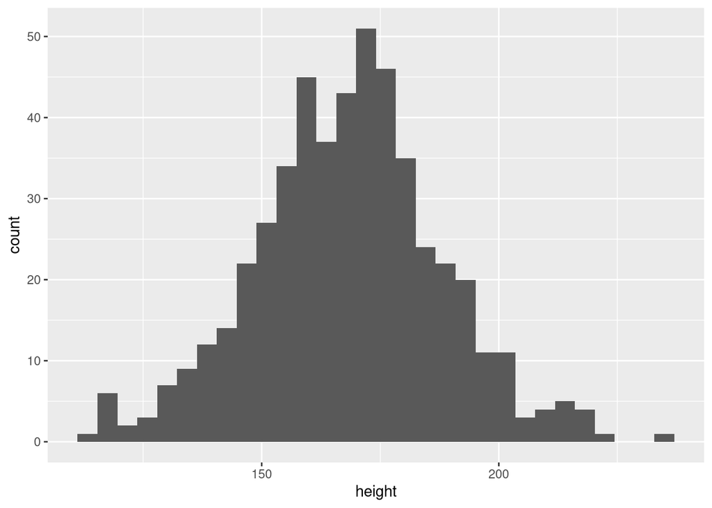

```r
ggplot(data, aes(x = height)) +
    geom_histogram()
```

We can also check the normality assumption:

```r
noisy <- function(x) {
    return(x + rnorm(length(x), sd = mean(x) * 1e-10))
}

normality_test <- function(x) {
    print(shapiro.test(x))
    n <- length(x)
    x_mean <- mean(x)
    x_sd <- sd(x)
    print(ks.test(noisy(x), "pnorm", x_mean, x_sd))
}

normality_test(data$height)
```

```
##
##  Shapiro-Wilk normality test
##
## data:  x
## W = 0.99662, p-value = 0.3778
##
##
##  One-sample Kolmogorov-Smirnov test
##
## data:  noisy(x)
## D = 0.029919, p-value = 0.762
## alternative hypothesis: two-sided
```

So we have no reason to assume `height` is not normally distributed. At any rate, here’s the test itself:

```r
t.test(data$height, alternative = "less", mu = 170)
```

```
##
##  One Sample t-test
##
## data:  data$height
## t = -2.0699, df = 499, p-value = 0.01949
## alternative hypothesis: true mean is less than 170
## 95 percent confidence interval:
##     -Inf 169.629
## sample estimates:
## mean of x
##  168.1804
```

## 3.2. Median

Let’s spell out the hypotheses: $H_0$ is that they median of height is $165$ cm, $H_1$ that it is less than that.

We can use Wilcoxon signed-ranks test for $X = {\tt height}$, $Y = 165 \text{ cm}$. The test assumes that the pairs come from the same population, are sampled independently and randomly, and that the data is on the interval scale [(Wikipedia)](https://en.wikipedia.org/wiki/Wilcoxon_signed-rank_test); these are of course fine to assume. Thus:

```r
wilcox.test(data$height, alternative = "less", mu = 165)
```

```
##
##  Wilcoxon signed rank test with continuity correction
##
## data:  data$height
## V = 74416, p-value = 0.9999
## alternative hypothesis: true location is less than 165
```

```r
cat("med(height) = ", median(data$height), "\n", sep = "")
```

```
## med(height) = 168.965
```

We aren’t given any confidence levels, but clearly in the first case $H_0$ should be rejected in favor of $H_1$, whereas in the second case it shouldn’t. Note that it doesn’t mean that the median is 165 cm, only that it being less than that is even less acceptable.

# 4. CI

We are to give CIs at specificity level $\gamma = 0.99$ for `age`.

```r
gamma <- 0.99
alpha <- 1.0 - gamma
```

Let’s first look at this variable:

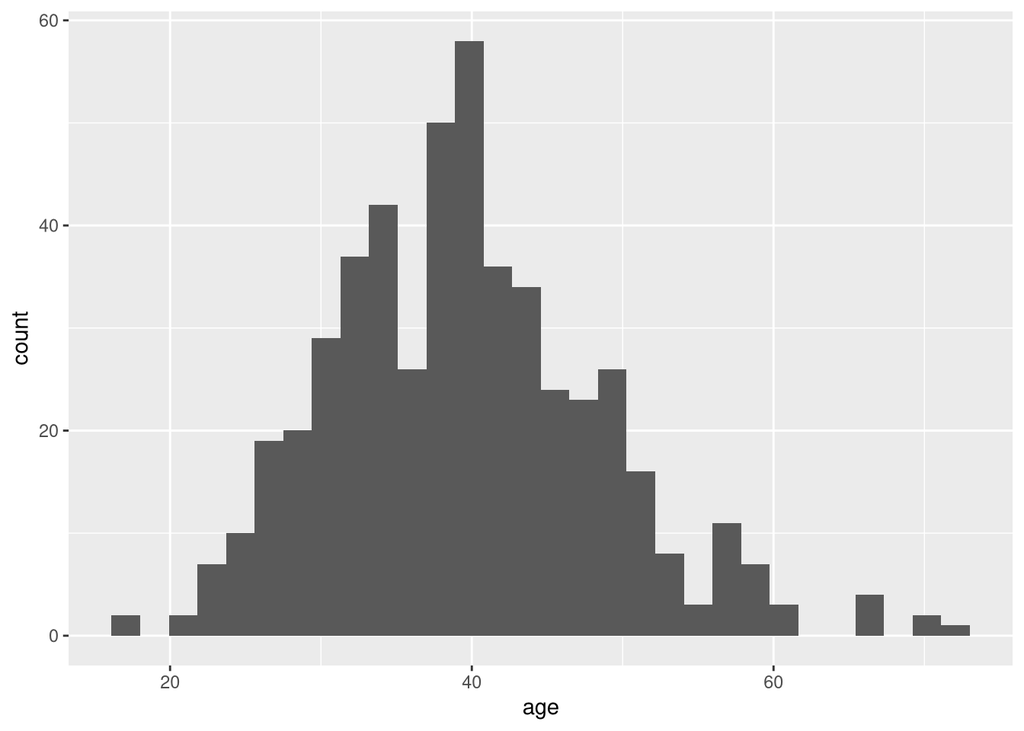

```r
ggplot(data, aes(x = age)) +
    geom_histogram()
```

This is quite an unusual age distribution. In fact, it looks somewhat like a normal distribution, even though in real life this doesn’t hold. “Numerically”:

```r
normality_test(data$age)
```

```
##
##  Shapiro-Wilk normality test
##
## data:  x
## W = 0.98179, p-value = 6.589e-06
##
##
##  One-sample Kolmogorov-Smirnov test
##
## data:  noisy(x)
## D = 0.08108, p-value = 0.002793
## alternative hypothesis: two-sided
```

Note: henceforth `age` shall be refered to as $X$.

## 4.1. $\mu$

For the mean, CLT suffices to derive reasonable CI even for a non-normal $X$. Indeed, we may assume $(\bar{X} - \mu)/(S/\sqrt{n}) \sim t(n-1)$, from which the intervals are:

$$\left(X + \frac{q(\alpha/2)}{\sqrt{n}}S, X + \frac{q(1-\alpha/2)}{\sqrt{n}}S\right)$$

```r
age_mean <- mean(data$age)
age_sd <- sd(data$age)
n <- length(data$age)
df <- n - 1
mu_low <- age_mean + qt(alpha / 2, df) / sqrt(n) * age_sd
mu_high <- age_mean + qt(1 - alpha / 2, df) / sqrt(n) * age_sd
cat(
    "CI for mean = (",
    mu_low, ", ", mu_high, ")", "\n",
    sep = ""
)
```

```
## CI for mean = (38.446, 40.522)
```

## 4.2. $\sigma$

Here the matters become somewhat complicated, so let’s assume that $X$ is close enough to a normal distribution that $nS^2/\sigma^2 \sim \chi^2(n-1)$ holds, so that we can get:

$$\left(\sqrt{\frac{nS^2}{\chi^2(1-\alpha/2, n-1)}}, \sqrt{\frac{nS^2}{\chi^2(\alpha/2, n-1)}}\right)$$

```r
sd_low <- sqrt(n * age_sd**2 / qchisq(1 - alpha / 2, df))
sd_high <- sqrt(n * age_sd**2 / qchisq(alpha / 2, df))
cat("CI for sd = (",
    sd_low, ", ", sd_high, ")", "\n",
    sep = ""
)
```

```
## CI for sd = (8.304853, 9.777896)
```

## 4.3. Quantiles

**Note:** (Essentially) taken from [Stack](https://stats.stackexchange.com/questions/99829/how-to-obtain-a-confidence-interval-for-a-percentile).

Here I am not aware of any explicit formula for even the normal distribution. We must therefore resort to outright definitions. For a quantile $q$, assuming $X$ is distributed with a cdf $F$, $F^{-1}(q)$ is what we are after; in general for a sample $X_1, \ldots, X_n$, we expect each of $X_i$ to have a chance $q$ of being less than $F^{-1}(q)$, so the total number of such $X_i$’s should be distributed like Binom($n$, $q$). If we sort $X_i$ as $X_{(1)} \leq \ldots \leq X_{(n)}$, one reasonable option is to pick as the confidence interval $[X_{(l)}, X_{(u)}]$ as small as possible, for which $B(u; n, q) - B(l; n, q) \geq \gamma$ (Note: boundary errors may follow, I didn’t really want to bother with index checking).

```r
quantile_ci <- function(q) {
    d <- round(sqrt(n))

    l <- qbinom(alpha / 2, n, q) + (-d:d)
    l[l <= 0] <- -Inf

    u <- qbinom(1 - alpha / 2, n, q) + (-d:d)
    u[u > n] <- Inf

    sorted_age <- sort(data$age)

    xls <- outer(l, u, function(xl, xu) xl)
    xus <- outer(l, u, function(xl, xu) xu)

    cover <- function(xl, xu) pbinom(xu, n, q) - pbinom(xl, n, q)
    covers <- outer(l, u, cover)

    span <- function(xl, xu) sorted_age[xu] - sorted_age[xl]
    spans <- outer(l, u, span)

    if (max(covers) < gamma) {
        i <- which(spans == max(spans))[1]
    }
    else {
        i <- which(spans == min(spans[covers >= gamma]))[1]
    }

    return(list(l = sorted_age[xls[i]], u = sorted_age[xus[i]]))
}

for (q in c(0.25, 0.5, 0.75)) {
    q_ci <- quantile_ci(q)
    cat("CI for quantile ", q, " = (", q_ci$l, ", ", q_ci$u, ")",
        "\n",
        sep = ""
    )
}
```

```
## CI for quantile 0.25 = (31, 34)
## CI for quantile 0.5 = (37, 39)
## CI for quantile 0.75 = (42, 46)
```

We can try to compare it to a heurestic: let’s assume $X \sim \mathcal{N}(\hat{\mu}, S)$ so as to get:

```r
quantile_ci_v2 <- function(q) {
    ci_low_idx <- qbinom(alpha / 2, n, q)
    ci_low <- qnorm(ci_low_idx / n, mean = age_mean, sd = age_sd)

    ci_high_idx <- qbinom(1 - alpha / 2, n, q)
    ci_high <- qnorm(ci_high_idx / n, mean = age_mean, sd = age_sd)

    return(list(l = ci_low, u = ci_high))
}

for (q in c(0.25, 0.5, 0.75)) {
    q_ci <- quantile_ci_v2(q)
    cat("CI for quantile ", q, " = (", q_ci$l, ", ", q_ci$u, ")\n", sep = "")
}
```

```
## CI for quantile 0.25 = (31.99325, 34.7768)
## CI for quantile 0.5 = (38.17435, 40.79365)
## CI for quantile 0.75 = (44.1912, 46.97475)
```

Indeed they are fairly similar.

# 5. Hypothesis testing II

```r
alpha <- 0.01
gamma <- 1 - alpha
```

## 5.1. `height` difference for men and women.

We will check whether $\mu({\tt height})$ is different for men and women. We chose this particular variable because (i) we have a clear intuition as to what sort of result we should get, (ii) we already checked that it’s fair to assume that `height` is normally distributed, so we can use $t$-test. As for the formal hypotheses, $H_0$ is that the means are the same for men and women, $H_1$ that they are not.

```r
men_height <- data$height[data$gender == "man"]
women_height <- data$height[data$gender == "woman"]
t.test(men_height, women_height, conf.level = gamma)
```

```
##
##  Welch Two Sample t-test
##
## data:  men_height and women_height
## t = 1.3099, df = 457.54, p-value = 0.1909
## alternative hypothesis: true difference in means is not equal to 0
## 99 percent confidence interval:
##  -2.349716  7.171254
## sample estimates:
## mean of x mean of y
##  169.6021  167.1913
```

So, although there’s clearly something here, we cannot (at $\alpha = 0.01$) reject the null hypothesis.

## 5.2. (In)dependence of two quantitative variables.

Let’s pick `weight` and `age`. We will use Spearman’s $\rho$. Let us note that we may have to introduce noise in order to prevent ties for the method to work. $H_0$ is that they are independent, $H_1$ that they are dependent.

But first, a graph:

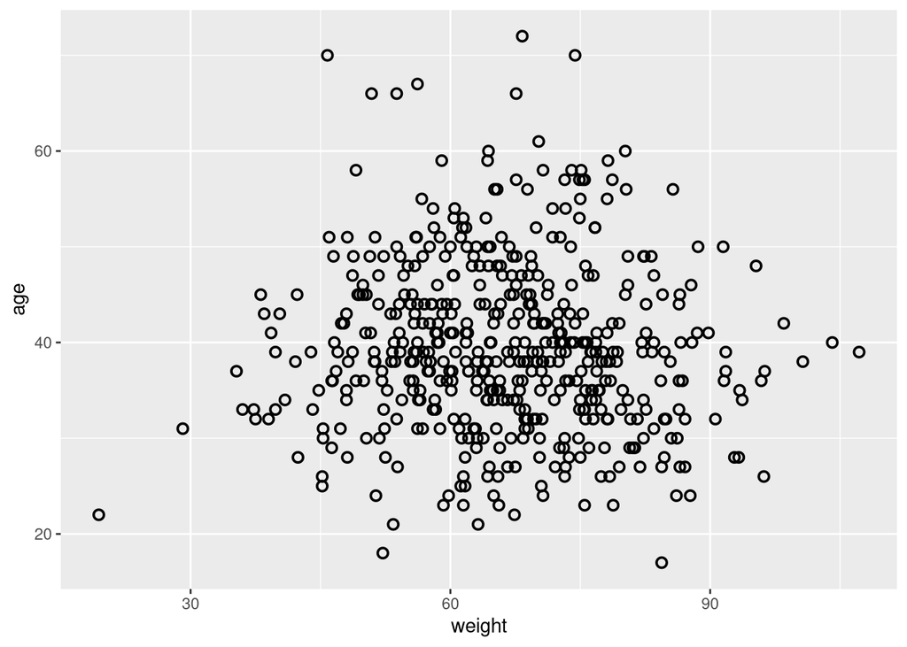

```r
ggplot(data, aes(x = weight, y = age)) +
    geom_point(shape = 21, size = 2, stroke = 1)
```

```r
cor.test(data$weight, data$age,
    alternative = "two.sided",
    conf.level = gamma,
    method = "spearman"
)
```

```
##
##  Spearman's rank correlation rho
##
## data:  data$weight and data$age
## S = 22163881, p-value = 0.1538
## alternative hypothesis: true rho is not equal to 0
## sample estimates:
##         rho
## -0.06387056
```

An easy method to fix the problem with ties is to introduce noise.

```r
cor.test(noisy(data$weight), noisy(data$age),
    alternative = "two.sided",
    conf.level = gamma,
    method = "spearman"
)
```

```
##
##  Spearman's rank correlation rho
##
## data:  noisy(data$weight) and noisy(data$age)
## S = 22179350, p-value = 0.1491
## alternative hypothesis: true rho is not equal to 0
## sample estimates:
##         rho
## -0.06461306
```

There is therefore no reason to reject the null hypothesis (i.e. independence).

## 5.3. (In)dependence of two qualitative variables

Let’s compare `gender` and `pet`. We shall use Pearson’s $\chi^2$. Formal hypotheses are as before.

Graph:

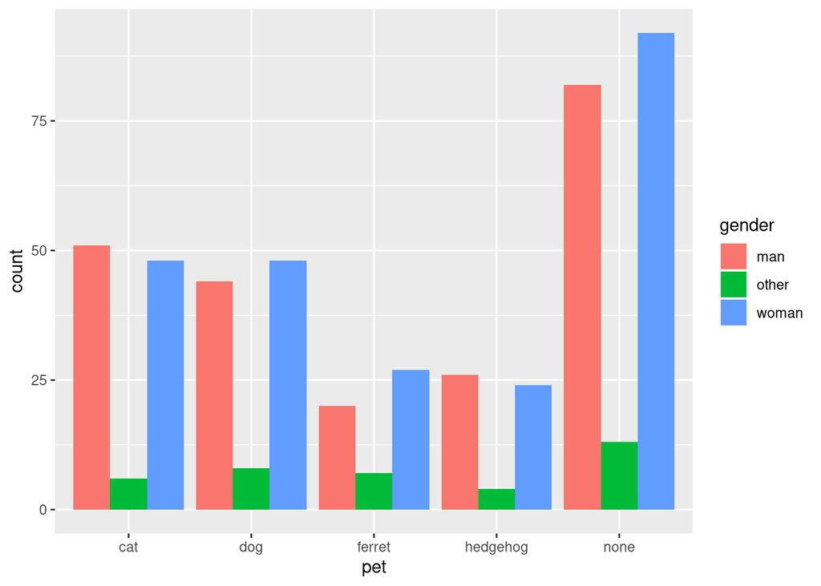

```r
ggplot(data, aes(pet, ..count..)) +
    geom_bar(aes(fill = gender), position = "dodge")
```

Test:

```r
chisq.test(data$gender, data$pet)
```

```
##
##  Pearson's Chi-squared test
##
## data:  data$gender and data$pet
## X-squared = 4.2645, df = 8, p-value = 0.8325
```

Given the $p$ value, there is no reason to reject the null hypothesis.

## 5.4. Equality of distributions

We have already checked `height` and `age`, wherefore I shall skip further elaboration here.

# 6. Linear model

Looking at the correlation graphs in (2), I can’t think of any meaningful feature augmentation to use. Thus, let’s look at the model as it stands:

```r
frm <- paste("expenses ~ ", paste(pred, collapse = " + "))
model <- lm(frm, data)
summary(model)
```

```
##
## Call:
## lm(formula = frm, data = data)
##
## Residuals:
##     Min      1Q  Median      3Q     Max
## -768.28 -127.24   -2.79  130.54  905.98
##
## Coefficients:
##                  Estimate Std. Error t value Pr(>|t|)
## (Intercept)    -2276.7455   100.1447 -22.735  < 2e-16 ***
## age               57.5889     1.0712  53.759  < 2e-16 ***
## weight             1.2078     0.9984   1.210  0.22698
## height             2.0637     0.6580   3.136  0.00182 **
## genderother       44.1656    37.7199   1.171  0.24222
## genderwoman      -21.7164    20.1406  -1.078  0.28146
## marriedTRUE       -9.8079    25.9461  -0.378  0.70559
## number_of_kids   -12.4393     8.8614  -1.404  0.16103
## petdog            29.2695    30.0801   0.973  0.33101
## petferret        406.6324    36.3026  11.201  < 2e-16 ***
## pethedgehog      242.0460    35.9101   6.740 4.47e-11 ***
## petnone           21.7454    26.2294   0.829  0.40748
## ---
## Signif. codes:  0 '***' 0.001 '**' 0.01 '*' 0.05 '.' 0.1 ' ' 1
##
## Residual standard error: 213.9 on 488 degrees of freedom
## Multiple R-squared:  0.861,  Adjusted R-squared:  0.8579
## F-statistic: 274.9 on 11 and 488 DF,  p-value: < 2.2e-16
```

Let’s now check what feature to remove:

```
##    (Intercept)            age         weight         height    genderother    genderwoman
##   1.451041e-78  3.740632e-207   2.269837e-01   1.815089e-03   2.422168e-01   2.814612e-01
##    marriedTRUE number_of_kids         petdog      petferret    pethedgehog        petnone
##   7.055867e-01   1.610268e-01   3.310091e-01   4.489195e-26   4.471211e-11   4.074840e-01
```

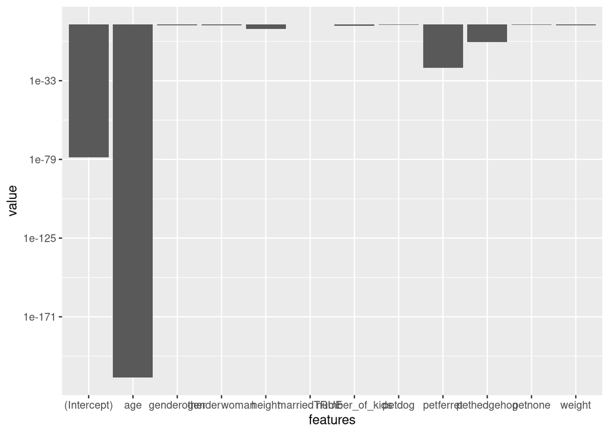

```r
full_r2 <- summary(model)$r.squared
full_rss <- deviance(model)

diff_r2 <- c()
diff_rss <- c()
pvalues <- summary(model)$coefficients[, 4]

for (feat in pred) {
    part_pred <- setdiff(pred, c(feat))
    part_frm <- paste("expenses ~ ", paste(part_pred, collapse = " + "))
    part_model <- lm(part_frm, data)

    part_r2 <- summary(part_model)$r.squared
    part_rss <- deviance(part_model)

    diff_r2[feat] <- full_r2 - part_r2
    diff_rss[feat] <- full_rss - part_rss
}

plotvs <- function(v) {
    df <- data.frame(features = names(v), value = v)
    print(v)
    ggplot(df, aes(features, value)) +
        geom_col() +
        scale_y_log10()
}

plotvs(pvalues)
```

```
##            age         weight         height         gender        married number_of_kids
##   8.229072e-01   4.166793e-04   2.800592e-03   1.000355e-03   4.068771e-05   5.610982e-04
##            pet
##   5.346147e-02
```

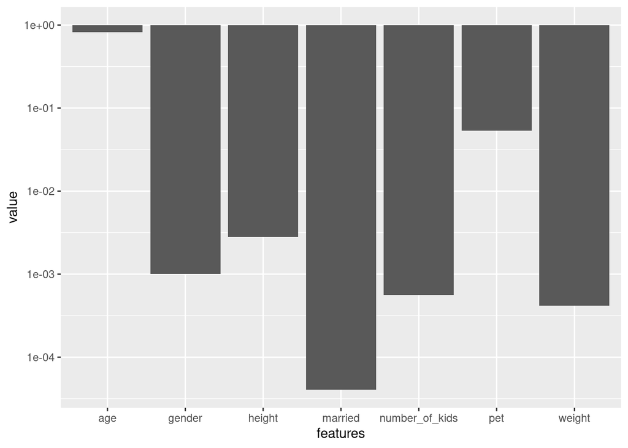

```r
plotvs(diff_r2)
```

```
##            age         weight         height         gender        married number_of_kids
##   1.322304e+08   6.695492e+04   4.500185e+05   1.607440e+05   6.537982e+03   9.016114e+04
##            pet
##   8.590559e+06
```

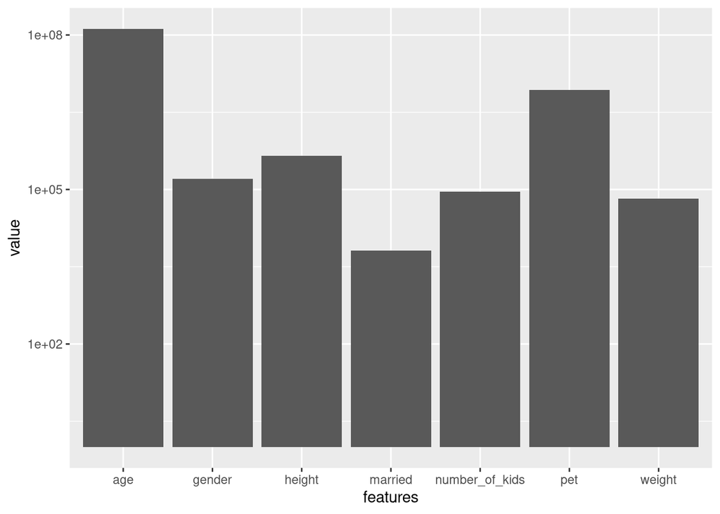

```r
plotvs(-diff_rss)
```

So, seemingly, we should remove `married`. We shall now investigate the model assumptions.

## Data nonlinearity

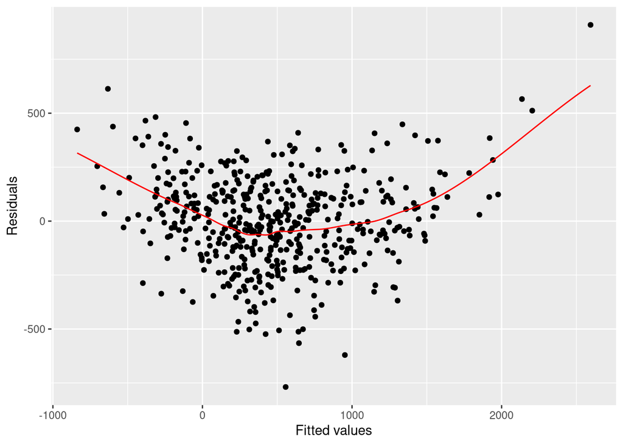

```r
redux_pred <- setdiff(pred, c("married"))
redux_frm <- paste("expenses ~ ", paste(redux_pred, collapse = " + "))
redux_model <- lm(redux_frm, data)

res <- resid(redux_model)
predv <- predict(redux_model)

fit <- loess(res ~ predv, degree = 1, span = 1 / 3)
x1 <- seq(min(predv), max(predv), len = 500)
fit_res <- predict(fit, data.frame(predv = x1))

ggplot() +
    geom_point(aes(x = predv, y = res)) +
    geom_line(aes(x = x1, y = fit_res), color = "red") +
    labs(x = "Fitted values", y = "Residuals")
```

## Non-constant variance of error terms

Nothing really obvious comes to my mind when I look at the diagram above.

## Outliers

Here one should investigate the diagram with fitted values against Studentized residuals.

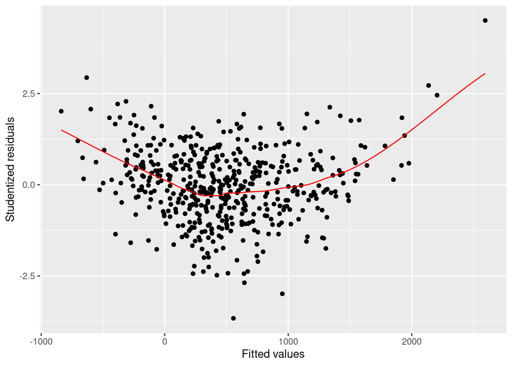

```r
sr <- studres(redux_model)

fit <- loess(sr ~ predv, degree = 1, span = 1 / 3)
x1 <- seq(min(predv), max(predv), len = 500)
fit_sr <- predict(fit, data.frame(predv = x1))

ggplot() +
    geom_point(aes(x = predv, y = sr)) +
    geom_line(aes(x = x1, y = fit_sr), color = "red") +
    labs(x = "Fitted values", y = "Studentized residuals")
```

I wouldn’t say there’s any obvious outlier, perhaps except for the far-right point.

## High leverage points

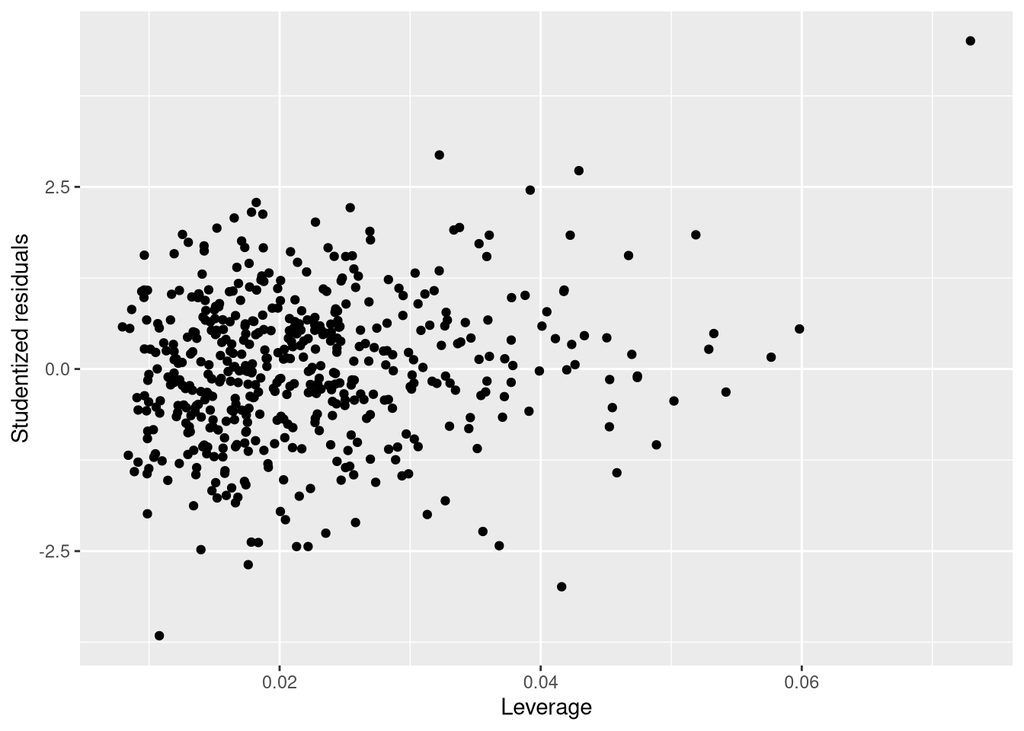

```r
lev <- leverage(redux_model)

ggplot() +
    geom_point(aes(x = lev, y = sr)) +
    labs(x = "Leverage", y = "Studentized residuals")
```

So, inasfar as high leverage points and outliers are concerned, I wouldn’t say it’s all that significant; I cannot, however, argue that the assumptions of a linear model (i.e. that the underlying data is actually linear with some degree of feature-independent noise) hold for this particular dataset.